# Sequence Read Distribution PFAS per Sample

```r
library(dplyr)
library(tibble)
library(ggplot2)
```

```r
library(scales)

# scale_y_continuous(labels = label_comma())      # 1,500,000
# or
# scale_y_continuous(labels = label_number(scale = 1e-6, suffix = "M"))  # 1.5M
```

The goal of this notebook: - see if there are some groups of samples with less reads - and see if PFBS has less reads than others leading to unclear results in DESeq2

“Bowtie 2 / HiSAT2 Results from both Bowtie 2 and HISAT2, tools for aligning reads against a reference genome.http://bowtie-bio.sourceforge.net/bowtie2; https://ccb.jhu.edu/software/hisat2DOI: 10.1038/nmeth.1923; 10.1038/nmeth.3317; 10.1038/s41587-019-0201-4 Single-end alignments This plot shows the number of reads aligning to the reference in different ways.”

import sequence mapped from multiqc (pfas manifest v1.2 - end2end)

```r
reads_distr <- read.table("~/Documents/School/thesis/PFAS_project_preprocessing_pipeline/Results_from_pipeline/bowtie/pfas_manifest_v1.2/end2end/pfas_v1.2_bowtie2_se_plot.tsv", header=TRUE, sep = "\t")
```

```r
reads_distr
```

| Sample | SE.mapped.uniquely | SE.multimapped | SE.not.aligned |
| --- | --- | --- | --- |
| SRR11022066_bowtie | 2469999 | 4547 | 1400722 |
| SRR11022065_bowtie | 1737911 | 3485 | 1002095 |
| SRR11022064_bowtie | 1984831 | 4060 | 1580831 |
| SRR11022063_bowtie | 2127459 | 3739 | 2265525 |
| SRR11022062_bowtie | 1456189 | 2297 | 1027199 |
| SRR11022061_bowtie | 1686158 | 2155 | 1096970 |
| SRR11022060_bowtie | 2998473 | 4757 | 1478123 |
| SRR11022059_bowtie | 2605363 | 4718 | 1713597 |
| SRR11022058_bowtie | 2110768 | 2753 | 1494229 |
| SRR11022057_bowtie | 1750518 | 2491 | 1093058 |

[output cut: 597 more lines]

Remove _bowtie from the column sample

```r
reads_distr$Sample <- gsub("_bowtie","",reads_distr$Sample)
```

import the metadata_all

```r
# import the metadata file from analysis app
metadata_pfas <- read.csv("/home/lawrence/Documents/School/thesis/PFAS_project_R-analysis/results_from_analysis/data_input_deseq/metadata_all.csv")  %>% select(X,SRR,chemical,duration,dose) %>% filter(chemical %in% c("DMSO_pfas","PFBS","PFOS","PFDS","PFOA")) %>% rename("Sample" = "SRR")
metadata_pfas
```

| X | Sample | chemical | duration | dose |
| --- | --- | --- | --- | --- |
| DMSO_pfas-1d-0uM | SRR11021467 | DMSO_pfas | 1 | 0e+00 |
| PFBS-14d-0.1uM | SRR11021960 | PFBS | 14 | 1e-01 |
| DMSO_pfas-1d-0uM-1 | SRR11021461 | DMSO_pfas | 1 | 0e+00 |
| PFBS-14d-0.1uM-1 | SRR11021961 | PFBS | 14 | 1e-01 |
| PFBS-14d-0.2uM | SRR11021963 | PFBS | 14 | 2e-01 |
| PFBS-14d-0.1uM-2 | SRR11021962 | PFBS | 14 | 1e-01 |
| PFBS-14d-0.1uM-3 | SRR11021959 | PFBS | 14 | 1e-01 |
| PFBS-14d-0.02uM | SRR11021958 | PFBS | 14 | 2e-02 |
| DMSO_pfas-1d-0uM-2 | SRR11021460 | DMSO_pfas | 1 | 0e+00 |
| DMSO_pfas-4d-0uM | SRR11021641 | DMSO_pfas | 4 | 0e+00 |

[output cut: 597 more lines]

```r
unique(metadata_pfas$chemical)
```

```
[1] "DMSO_pfas" "PFBS"      "PFDS"      "PFOA"      "PFOS"
```

Merge the reads_distr with the metadata_pfas

```r
merged_df <- full_join(metadata_pfas, reads_distr, by = "Sample")
merged_df
```

| X | Sample | chemical | duration | dose | SE.mapped.uniquely | SE.multimapped | SE.not.aligned |
| --- | --- | --- | --- | --- | --- | --- | --- |
| DMSO_pfas-1d-0uM | SRR11021467 | DMSO_pfas | 1 | 0e+00 | 4019747 | 6989 | 4014619 |
| PFBS-14d-0.1uM | SRR11021960 | PFBS | 14 | 1e-01 | 1671689 | 3007 | 1184851 |
| DMSO_pfas-1d-0uM-1 | SRR11021461 | DMSO_pfas | 1 | 0e+00 | 2476100 | 5064 | 2762304 |
| PFBS-14d-0.1uM-1 | SRR11021961 | PFBS | 14 | 1e-01 | 1841544 | 2639 | 1447049 |
| PFBS-14d-0.2uM | SRR11021963 | PFBS | 14 | 2e-01 | 2148882 | 3532 | 1291380 |
| PFBS-14d-0.1uM-2 | SRR11021962 | PFBS | 14 | 1e-01 | 1532652 | 1925 | 1075609 |
| PFBS-14d-0.1uM-3 | SRR11021959 | PFBS | 14 | 1e-01 | 1778641 | 3146 | 2299989 |
| PFBS-14d-0.02uM | SRR11021958 | PFBS | 14 | 2e-02 | 1571859 | 2145 | 1045068 |
| DMSO_pfas-1d-0uM-2 | SRR11021460 | DMSO_pfas | 1 | 0e+00 | 1823436 | 2924 | 2053294 |
| DMSO_pfas-4d-0uM | SRR11021641 | DMSO_pfas | 4 | 0e+00 | 2818246 | 5791 | 1488805 |

[output cut: 597 more lines]

Now group by chemical, duration, and dose

```r
merged_df_arranged <- merged_df %>% arrange(chemical,duration,dose)
merged_df_arranged
```

| X | Sample | chemical | duration | dose | SE.mapped.uniquely | SE.multimapped | SE.not.aligned |
| --- | --- | --- | --- | --- | --- | --- | --- |
| DMSO_pfas-1d-0uM | SRR11021467 | DMSO_pfas | 1 | 0e+00 | 4019747 | 6989 | 4014619 |
| DMSO_pfas-1d-0uM-1 | SRR11021461 | DMSO_pfas | 1 | 0e+00 | 2476100 | 5064 | 2762304 |
| DMSO_pfas-1d-0uM-2 | SRR11021460 | DMSO_pfas | 1 | 0e+00 | 1823436 | 2924 | 2053294 |
| DMSO_pfas-1d-0uM-3 | SRR11021463 | DMSO_pfas | 1 | 0e+00 | 4976885 | 9782 | 3127273 |
| DMSO_pfas-1d-0uM-4 | SRR11021464 | DMSO_pfas | 1 | 0e+00 | 3897860 | 7730 | 3259108 |
| DMSO_pfas-1d-0uM-5 | SRR11021466 | DMSO_pfas | 1 | 0e+00 | 2491562 | 5227 | 2069968 |
| DMSO_pfas-1d-0uM-6 | SRR11021462 | DMSO_pfas | 1 | 0e+00 | 4337862 | 7971 | 3940071 |
| DMSO_pfas-1d-0uM-7 | SRR11021465 | DMSO_pfas | 1 | 0e+00 | 2979103 | 5944 | 2468061 |
| DMSO_pfas-1d-0uM-8 | SRR11021474 | DMSO_pfas | 1 | 0e+00 | 1347129 | 2015 | 1247467 |
| DMSO_pfas-1d-0uM-9 | SRR11021468 | DMSO_pfas | 1 | 0e+00 | 3338047 | 5217 | 3166875 |

[output cut: 597 more lines]

Take the mean of mapped.uniquely of the replicates for each sample group (duration and dose)

```r
chemical_summary <- merged_df %>% group_by(chemical,duration,dose) %>%
  summarise(
    mean_unique_mapped = mean(SE.mapped.uniquely, na.rm = TRUE),
    total_samples = n()
  ) %>%
  arrange(chemical,duration,dose,mean_unique_mapped)

chemical_summary
```

| chemical | duration | dose | mean_unique_mapped | total_samples |
| --- | --- | --- | --- | --- |
| DMSO_pfas | 1 | 0e+00 | 2913958 | 32 |
| DMSO_pfas | 4 | 0e+00 | 2546060 | 32 |
| DMSO_pfas | 10 | 0e+00 | 1814056 | 33 |
| DMSO_pfas | 14 | 0e+00 | 1913593 | 31 |
| PFBS | 1 | 2e-02 | 2791361 | 3 |
| PFBS | 1 | 1e-01 | 2925775 | 4 |
| PFBS | 1 | 2e-01 | 2987589 | 4 |
| PFBS | 1 | 1e+00 | 3132646 | 4 |
| PFBS | 1 | 2e+00 | 2595082 | 4 |
| PFBS | 1 | 1e+01 | 3019985 | 4 |

[output cut: 127 more lines]

How about grouping just by chemical and duration, including dose would be too much

```r
chemical_summary <- merged_df %>% group_by(chemical,duration) %>%
  summarise(
    mean_unique_mapped = mean(SE.mapped.uniquely, na.rm = TRUE),
    total_samples = n()
  ) %>%
  arrange(chemical,duration,mean_unique_mapped)

chemical_summary
```

| chemical | duration | mean_unique_mapped | total_samples |
| --- | --- | --- | --- |
| DMSO_pfas | 1 | 2913958 | 32 |
| DMSO_pfas | 4 | 2546060 | 32 |
| DMSO_pfas | 10 | 1814056 | 33 |
| DMSO_pfas | 14 | 1913593 | 31 |
| PFBS | 1 | 2901917 | 34 |
| PFBS | 4 | 2863501 | 32 |
| PFBS | 10 | 1822753 | 31 |
| PFBS | 14 | 1930648 | 35 |
| PFDS | 1 | 2901251 | 35 |
| PFDS | 4 | 3031705 | 33 |

[output cut: 10 more lines]

Create a bar graph comparing them all

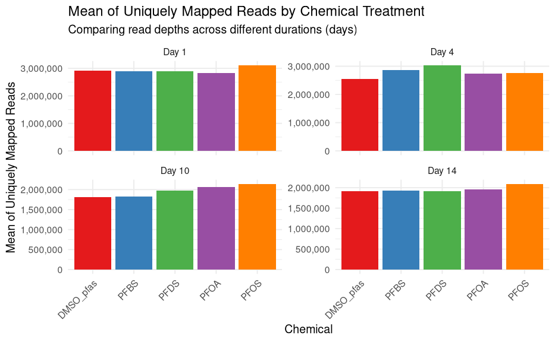

```r
ggplot(chemical_summary, aes(x = chemical, y = mean_unique_mapped, fill = chemical)) +
  geom_col(position = "dodge") + #stack is the other option
  facet_wrap(~ duration, scales = "free_y",
             labeller = labeller(duration = function(x) paste("Day", x))) +
              # apply function to facet variable to add "day"
  labs(
    title = "Mean of Uniquely Mapped Reads by Chemical Treatment",
    subtitle = "Comparing read depths across different durations (days)",
    x = "Chemical",
    y = "Mean of Uniquely Mapped Reads",
    fill = "Chemical"
  ) +
  theme_minimal() +
  scale_fill_brewer(palette = "Set1") +
  scale_y_continuous(labels = label_comma()) +     # 1,500,000
  theme(
    axis.text.x = element_text(angle = 45, hjust = 1), # Rotates chemical names so they don't overlap
    legend.position = "none" # Hide legend since X-axis labels already show the chemicals
  )
```

```r
chemical_summary_simple <- merged_df %>% group_by(chemical) %>%
  summarise(
    mean_unique_mapped = mean(SE.mapped.uniquely, na.rm = TRUE),
    total_samples = n()
  )

chemical_summary_simple
```

| chemical | mean_unique_mapped | total_samples |
| --- | --- | --- |
| DMSO_pfas | 2296139 | 128 |
| PFBS | 2381631 | 132 |
| PFDS | 2480030 | 130 |
| PFOA | 2435551 | 116 |
| PFOS | 2548278 | 101 |

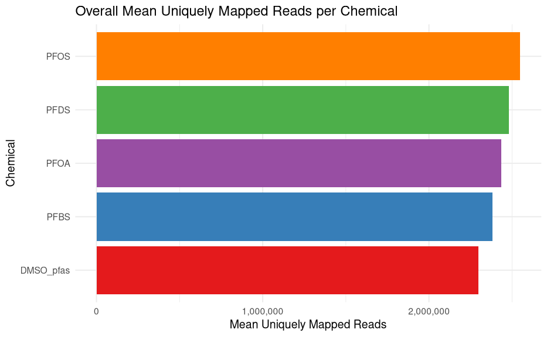

```r
ggplot(chemical_summary_simple, aes(x = reorder(chemical, mean_unique_mapped), y = mean_unique_mapped, fill = chemical)) +
  geom_col() +
  coord_flip() + # Horizontal bars are easier to read
  labs(
    title = "Overall Mean Uniquely Mapped Reads per Chemical",
    x = "Chemical",
    y = "Mean Uniquely Mapped Reads"
  ) +
  theme_minimal() +
  scale_fill_brewer(palette = "Set1") +
  scale_y_continuous(labels = label_comma()) +     # 1,500,000
  theme(legend.position = "none")
```

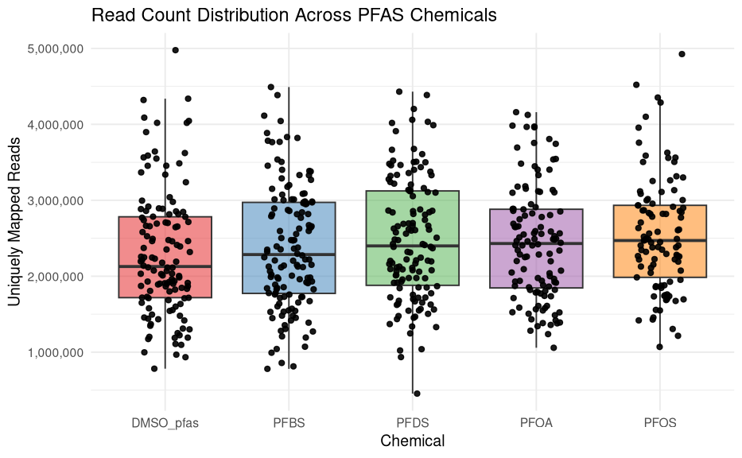

```r
ggplot(merged_df, aes(x = chemical, y = SE.mapped.uniquely, fill = chemical)) +
  geom_boxplot(alpha = 0.5, outlier.shape = NA) +
  geom_jitter(width = 0.2, alpha = 0.9) + # Shows individual samples as dots
  labs(
    title = "Read Count Distribution Across PFAS Chemicals",
    x = "Chemical",
    y = "Uniquely Mapped Reads"
  ) +
  theme_minimal() +
  scale_y_continuous(labels = label_comma()) +     # 1,500,000
  scale_fill_brewer(palette = "Set1") +
  theme(legend.position = "none")
```

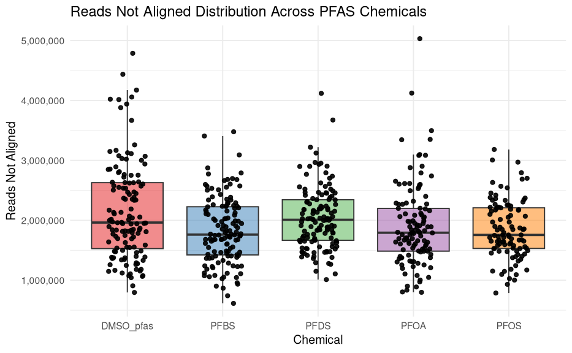

```r
ggplot(merged_df, aes(x = chemical, y = SE.not.aligned, fill = chemical)) +
# ggplot(merged_df, aes(x = chemical, y = SE.mapped.uniquely, fill = chemical)) +
  geom_boxplot(alpha = 0.5, outlier.shape = NA) +
  geom_jitter(width = 0.2, alpha = 0.9) + # Shows individual samples as dots
  labs(
    title = "Reads Not Aligned Distribution Across PFAS Chemicals",
    x = "Chemical",
    y = "Reads Not Aligned"
  ) +
  theme_minimal() +
  scale_y_continuous(labels = label_comma()) +     # 1,500,000
  scale_fill_brewer(palette = "Set1") +
  theme(legend.position = "none")
```

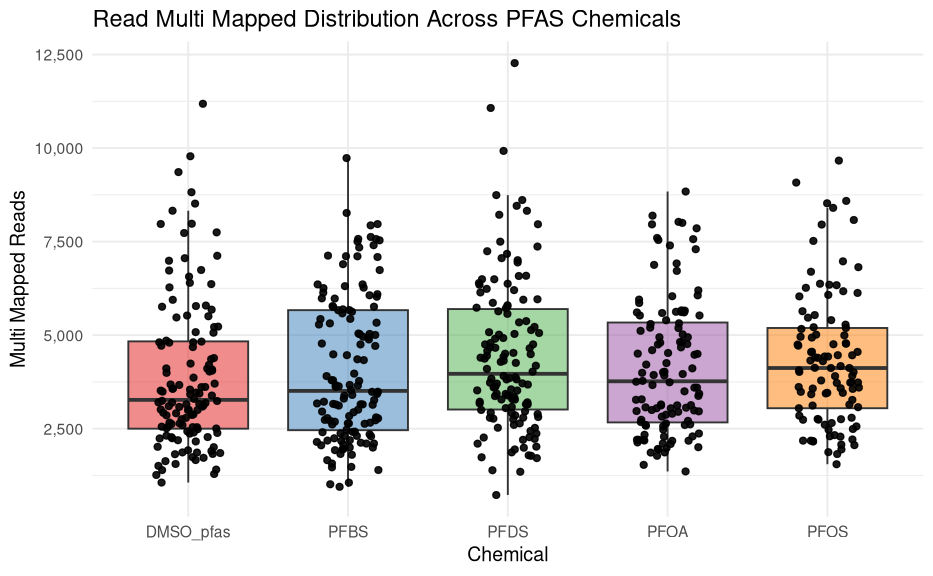

```r
ggplot(merged_df, aes(x = chemical, y = SE.multimapped, fill = chemical)) +
# ggplot(merged_df, aes(x = chemical, y = SE.mapped.uniquely, fill = chemical)) +
  geom_boxplot(alpha = 0.5, outlier.shape = NA) +
  geom_jitter(width = 0.2, alpha = 0.9) + # Shows individual samples as dots
  labs(
    title = "Read Multi Mapped Distribution Across PFAS Chemicals",
    x = "Chemical",
    y = "Multi Mapped Reads"
  ) +
  theme_minimal() +
  scale_y_continuous(labels = label_comma()) +     # 1,500,000
  scale_fill_brewer(palette = "Set1") +
  theme(legend.position = "none")
```